# Full Crypto Tax Report for Tax Year 2021

Name: Mr. Cryptoltruist

Date: Fri Feb 10 20:55:04 2023

### Summary

| Type | Amount | currency |
| --- | --- | --- |
| gains | 14.64 | CAD |
| losses | 0.00 | CAD |
| net | 14.64 | CAD |
| total.cost | 36.40 | CAD |
| value.today | NA | CAD |
| unrealized.gains | 0.00 | CAD |
| unrealized.losses | 0.00 | CAD |
| unrealized.net | 0.00 | CAD |
| percentage.up | NA% | CAD |
| all.time.up | NA% | CAD |

All time up in percentage (including all unrealized gains and revenues received) is NA%. In absolute dollars, that is 80.92 CAD.

### Overview

| date.last | currency | total.quantity | cost.share | total.cost | gains | losses | net | currency2 |
| --- | --- | --- | --- | --- | --- | --- | --- | --- |
| 2021-07-10 00:52:19 | BTC | 0.0011599 | 31,384.02 | 36.40 | 14.64 | 0.00 | 14.64 | BTC |
| 2021-07-10 00:52:19 | Total |  |  | 36.40 | 14.64 | 0.00 | 14.64 | Total |

### Current Value

| currency | cost.share | total.cost | rate.today | value.today | unrealized.gains | unrealized.losses | unrealized.net | currency2 |
| --- | --- | --- | --- | --- | --- | --- | --- | --- |
| BTC | 31,384.02 | 36.40 |  |  |  |  |  | BTC |
| Total |  | 36.40 |  | 0.00 | 0.00 | 0 | 0.00 | Total |
| currency | cost.share | total.cost | rate.today | value.today | unrealized.gains | unrealized.losses | unrealized.net | currency2 |

### Superficial losses

| currency | sup.loss |
| --- | --- |
| Total | 0.00 |

### Revenues

| exchange | date.last | total.revenues | airdrops | referrals | staking | promos | interests | rebates | rewards | forks | mining | currency |
| --- | --- | --- | --- | --- | --- | --- | --- | --- | --- | --- | --- | --- |
| shakepay | 2021-06-23 12:21:49 | 66.28 | 36.28 | 30.00 | 0.00 | 0.00 | 0.00 | 0.00 | 0.00 | 0.00 | 0.00 | CAD |
| total | 2021-06-23 12:21:49 | 66.28 | 36.28 | 30.00 | 0.00 | 0.00 | 0.00 | 0.00 | 0.00 | 0.00 | 0.00 | CAD |
| exchange | date.last | total.revenues | airdrops | referrals | staking | promos | interests | rebates | rewards | forks | mining | currency |

### Revenue Sources by **Exchanges**

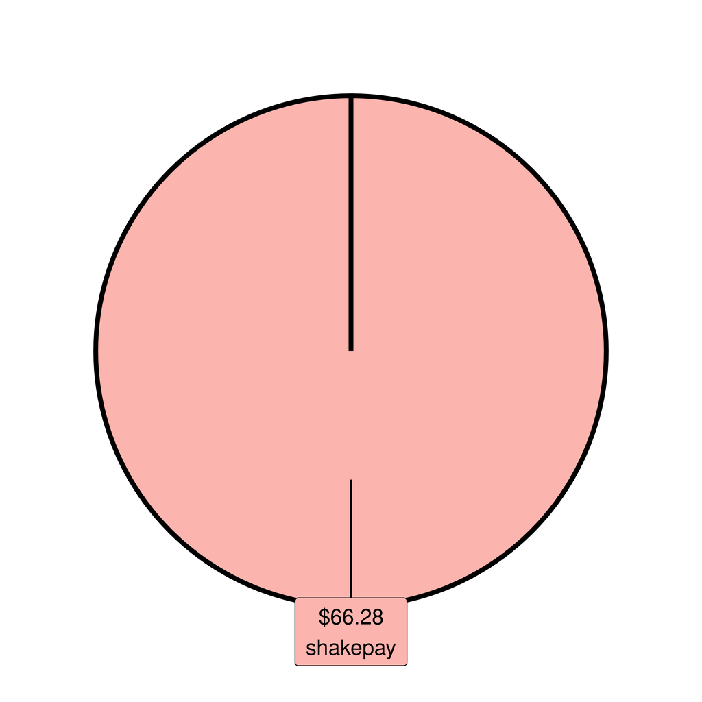

### Revenue Sources by **Types**

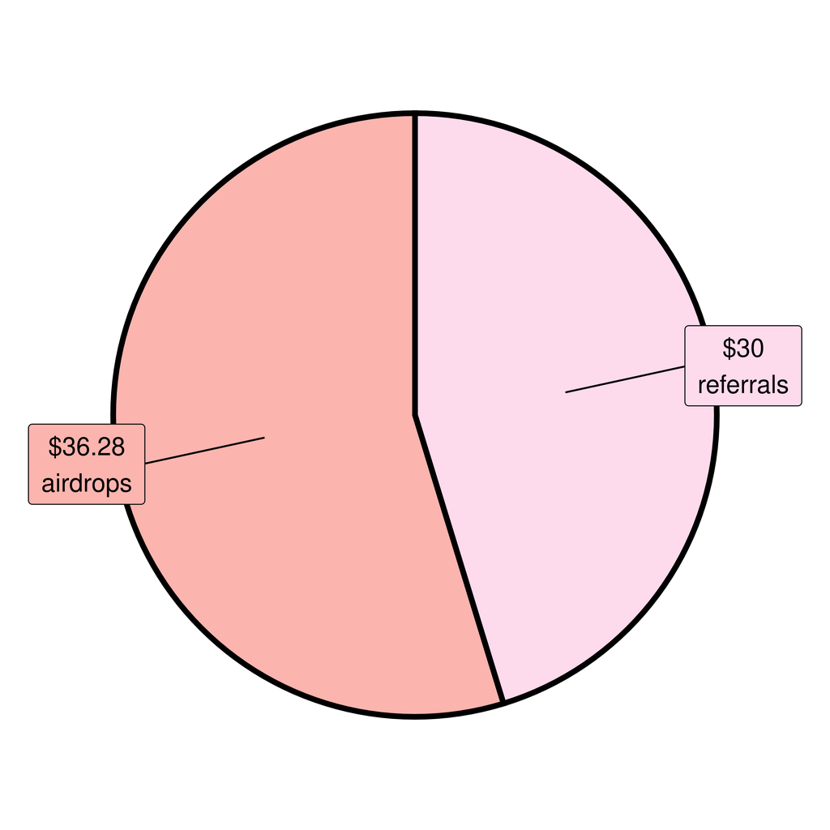

# Important Tax Information for Your Accountant

### Capital gains

Your **capital gains** for 2021 are **$14.64**, whereas your **capital losses** are **$0.00** (net = **$14.64**).

> Those are only taxed at 50%. Your **capital losses** are calculated as **total capital losses** (**$0**) - **superficial losses** (**$0**) = **actual capital losses** (**$0**).

Your total “proceeds” *for the coins you sold at a **profit*** is: **$31.27** (aggregated for all coins). Your total ACB *for the coins you sold at a profit* is: **$16.63** (average of all coins). The difference between the two is your capital gains: **$14.64**.

Your total “proceeds” (adjusted for superficial gains) *for the coins you sold at a **loss*** is: **$0.00** (aggregated for all coins). Your total ACB *for the coins you sold at a loss* is: **$0.00** (average of all coins). The difference between the two is your capital losses: **$0.00**.

### Income

Your **total taxable income** from crypto (from interest & staking exclusively) for 2021 is **$0.00**, which is considered 100% taxable income.

> *Note that per default, this amount excludes revenue from credit card cashback because it is considered rebate, not income, so considered acquired at the fair market value at the time of reception.* The income reported above also excludes other forms of airdrops and rewards (e.g., from Shakepay, Brave, Presearch), referrals, and promos, which are considered acquired at a cost of 0$ (and will thus incur a capital gain of 100% upon selling). Note that should you wish to give different tax treatment to the different transaction types, you can do so through the ‘as.revenue’ argument of the ‘ACB’ function. Mining rewards needs to be labelled individually in the files before using `format_ACB()`.

### Total tax estimation

In general, you can expect to pay tax on 50% (**$7.32**) of your net capital gains + 100% of your taxable income (**$0.00**), for a total of **$7.32**. This amount will be taxed based on your tax bracket.

> Note that if your capital gains are net negative for the current year, any excess capital losses can be deferred to following years. However, capital losses have to be used in the same year first if you have outstanding capital gains.

### Form T1135

If your **total acquisition cost** has been greater than **$100,000** at any point during 2021 (it is **$36.40** at the time of this report), you will need to fill **form T1135** (*Foreign Income Verification Statement*). Form T1135 is [available for download](https://www.canada.ca/content/dam/cra-arc/formspubs/pbg/t1135/t1135-fill-19e.pdf), and more information about it can be found on the [CRA website](https://www.canada.ca/en/revenue-agency/services/tax/international-non-residents/information-been-moved/foreign-reporting/questions-answers-about-form-t1135.html).

### Summary table

Here is a summary of what you need to enter on which lines of your income tax:

| Description | Amount | Comment | Line |
| --- | --- | --- | --- |
| Gains proceeds | 31.27 | Proceeds of sold coins (gains) | Schedule 3, line 15199 column 2 |
| Gains ACB | 16.63 | ACB of sold coins (gains) | Schedule 3, line 15199 column 3 |
| Gains | 14.64 | Proceeds - ACB (gains) | Schedule 3, lines 15199 column 5 & 15300 |
| 50% of gains | 7.32 | Half of gains | T1, line 12700; Schedule 3, line 15300, 19900 |
| Outlays of gains | 0.00 | Expenses and trading fees (gains). Normally already integrated in the ACB | Tax software |
| Losses proceeds | 0.00 | Proceeds of sold coins (losses) | Schedule 3, line 15199 column 2 |
| Losses ACB | 0.00 | ACB of sold coins (losses) | Schedule 3, line 15199 column 3 |
| Losses | 0.00 | Proceeds - ACB (losses) | Schedule 3, lines 15199 column 5 & 15300 |
| 50% of losses | 0.00 | Half of losses | T1, line 12700; Schedule 3, line 15300, 19900 |
| Outlays of losses | 0.00 | Expenses and trading fees (losses). Normally already integrated in the ACB | Tax software |
| Foreign income | 0.00 | Income from crypto interest or staking is considered foreign income | T1, line 12100, T1135 |
| Foreign gains | 14.64 | Capital gains from crypto is considered foreign capital gains | T1135 |

### Other situations

If applicable, you may also need to enter the following:

> Interest expense on money borrowed to purchase investments for the purpose of gaining or producing income is tax-deductible. Use line 22100 (was line 221) of the personal income tax return, after completion of Schedule 4 (federal).

……………………………………………………………………………………………………………………………………………………………………………….